[Portfolio Home](https://jmerchen.github.io/Jackson_Merchen.github.io/index.html)

# The Student Debt Crisis

Jackson Merchen

July 12, 2022

```r
Min_Wage <- read_csv("~/Downloads/Minimum Wage Data.csv")
Min_Wage <- Min_Wage %>%
  filter(Year > 1989) %>%
  group_by(Year) %>%
  summarise(`Average State Minimum Wage` = mean(State.Minimum.Wage),
            `Federal Minimum Wage` = Federal.Minimum.Wage) %>%
  distinct()

Min_Wage$Year <- as.character(Min_Wage$Year)

Min_Wage <- Min_Wage %>%
  mutate(`Min Wage Change` = `Average State Minimum Wage`/3.54 - 1)

US_Income <- read_excel("~/Downloads/US_Income.xlsx")
US_Income <- US_Income %>%
  separate(Year, into = "Year", sep = 4) %>%
  mutate(`Income Change` = `Current\r\ndollars`/16555 - 1)

US_Income <- US_Income %>%
  mutate(`Average Income` = `Current\r\ndollars`)

US_Gas <- read_excel("~/Downloads/US_Gas.xls")
US_Gas$Date <- format(US_Gas$Date, format = "%Y")

US_Gas$Year <- US_Gas$Date

US_Gas <- US_Gas %>%
  mutate(`Gas Change` = `U.S. All Grades All Formulations Retail Gasoline Prices (Dollars per Gallon)`/1.078 - 1)

US_Gas <- US_Gas %>%
  mutate(`Average Gas Price` = `U.S. All Grades All Formulations Retail Gasoline Prices (Dollars per Gallon)`)

US_Consumption <- read_excel("~/Downloads/US_Consumption.xlsx")

US_Consumption$Year <- as.character(US_Consumption$Year)

US_Consumption <- US_Consumption %>%
  mutate(`Consumption Change` = `US Consumption`/31731 - 1)

US_Consumption <- US_Consumption %>%
  mutate(`Average Yearly Consumption` = `US Consumption`)

US_Houses <- read_csv("~/Downloads/US_Houses.csv")
US_Houses$Year <- format(US_Houses$DATE, format = "%Y")

US_Houses <- US_Houses %>%
  mutate(`Housing Change` = ASPUS/154175 - 1)

US_Houses <- US_Houses %>%
  mutate(`Average House Price` = ASPUS)

US_Tuition <- read_excel("~/Downloads/US_Tuition.xlsx")
US_Tuition$Year <- as.character(US_Tuition$`Academic Year`)

US_Tuition <- US_Tuition %>%
  mutate(`Tuition Change` = `Public Four-Year...4`/2710 - 1)

US_Tuition <- US_Tuition %>%
  mutate(`Average Tuition` = `Public Four-Year...4`)

Main <- Min_Wage %>%
  left_join(US_Income, by = "Year") %>%
  left_join(US_Gas, by = "Year") %>%
  left_join(US_Consumption, by = "Year") %>%
  left_join(US_Houses, by = "Year") %>%
  left_join(US_Tuition, by = "Year")

Main$Year <- as.double(Main$Year)

Main <- Main %>%
  filter(Year > 1993)

NowChange <- Main %>%
  filter(Year == "2020") %>%
  select(Year,`Min Wage Change`, `Income Change`, `Gas Change`, `Consumption Change`, `Housing Change`, `Tuition Change`) %>%
  pivot_longer(!Year, names_to = "Type", values_to = "Change")

NowThen <- Main %>%
  filter(Year == "2020" | Year == "1994") %>%
  select(Year,`Average State Minimum Wage`, `Average Income`, `Average Gas Price`, `Average Yearly Consumption`, `Average House Price`, `Average Tuition`) %>%
  pivot_longer(!Year, names_to = "Type in US$", values_to = "Average") %>%
  pivot_wider(names_from = Year, values_from = "Average") %>%
  mutate(Change = `2020` - `1994`) %>%
  mutate(`Percent Growth` = (`2020`/`1994` - 1) * 100)

RightTuition <- NowThen %>%
  filter(`Type in US$` != "Average Tuition") %>%
  summarise(`New Tuition` = mean(`Percent Growth`)/100)

NewTuition <- RightTuition*2710

Debt <- read_excel("~/Downloads/PortfolioSummary.xls")
```

## Introduction

*What accounts for the steady increase in outstanding student loans despite the recent decrease in college undergraduates?*

*What can students in the near future expect to pay for college? What debt will this leave them with?*

### The Numbers Behind College Educations

High schools and employers are putting an emphasis more than ever on college education, but the increase in undergraduates has not followed:

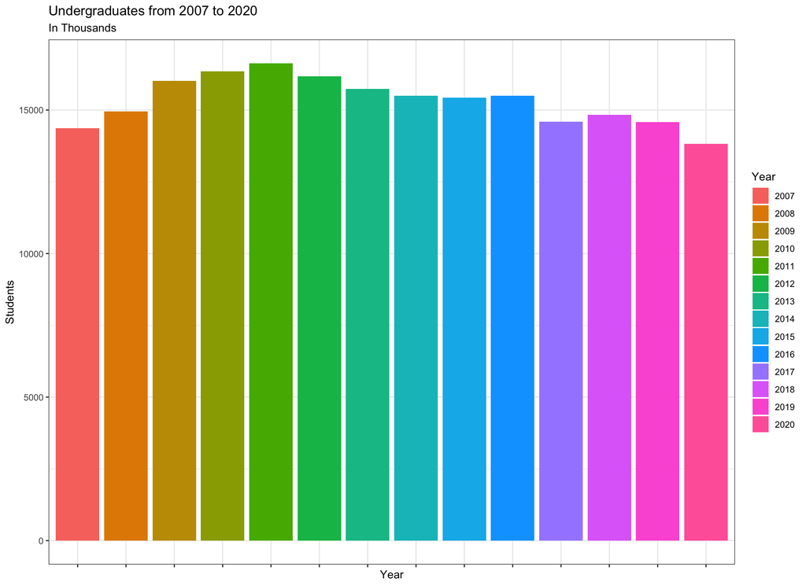

```r
Students <- read_excel("~/Downloads/tablea-7.xlsx")
Students <- Students %>%
  filter(Year > 2006)
ggplot(data = Students) +
  geom_bar(aes(x = Year, y = Students, fill = Year), stat = "identity") +
  ggtitle("Undergraduates from 2007 to 2020", "In Thousands") +
  theme_bw() +
  theme(axis.text.x = element_blank())
```

The amount of people attending college as undergraduates only increased slightly from 2007 to 2011, and, since 2012, has been declining. The amount of people with student loans in 2022 compared to 2007 has only increased 15 million, about half the amount of recipients in 2007 (an increase of only 53.4%). The amount of dollars outstanding in student loans, on the other hand, has more than tripled in that time. This can be seen in the plot and chart below:

```r
pander(Debt)
```

| Federal Fiscal Year2 | Dollars Outstanding (in billions) | Unduplicated Recipients (in millions) |
| --- | --- | --- |
| 2007 | 516 | 28.3 |
| 2008 | 577 | 29.9 |
| 2009 | 657 | 32.1 |
| 2010 | 749.8 | 34.3 |
| 2011 | 848.2 | 36.5 |
| 2012 | 948.2 | 38.3 |
| 2013 | 1040 | 39.6 |
| 2014 | 1130 | 40.7 |
| 2015 | 1212 | 41.6 |
| 2016 | 1292 | 42.3 |
| 2017 | 1367 | 42.6 |
| 2018 | 1439 | 42.9 |
| 2019 | 1510 | 42.9 |
| 2020 | 1566 | 42.9 |
| 2021 | 1611 | 43.4 |
| 2022 | 1606 | 43.4 |

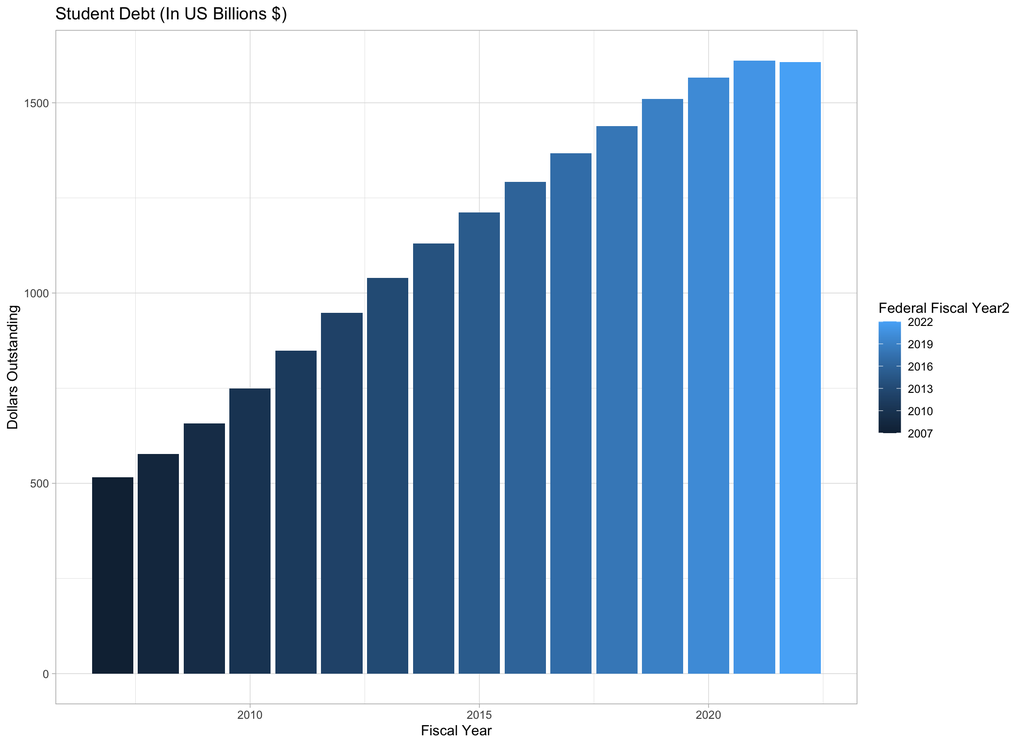

```r
ggplot(data = Debt) +
  geom_bar(aes(`Federal Fiscal Year2`, `Dollars Outstanding            (in billions)`, fill = `Federal Fiscal Year2`), stat = "identity") +
  ylab("Dollars Outstanding") +
  theme_light() +
  ggtitle("Student Debt (In US Billions $)") +
  xlab("Fiscal Year")
```

### Changes Since 1994

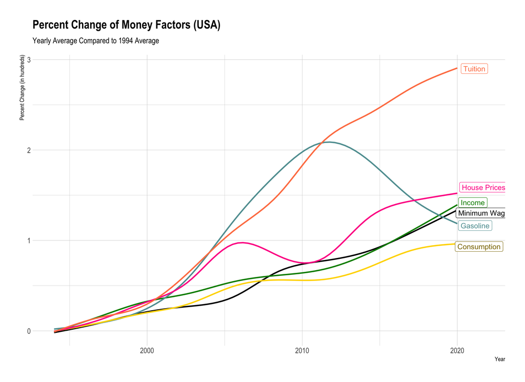

```r
ggplot() +
  geom_smooth(data = Main, aes(Year, `Min Wage Change`), colour = "black", se = F, method = "gam") +
  geom_label(data = Main %>% filter(Year == "2020"), aes(2020, `Min Wage Change`, label = "Minimum Wage"), nudge_x = 1.7, nudge_y = -.01) +
  geom_smooth(data = Main, aes(Year, `Income Change`), colour = "green4", se = F, method = "gam") +
  geom_label(data = Main %>% filter(Year == "2020"), aes(2020, `Income Change`, label = "Income"), nudge_x = 1, nudge_y = .06, colour = "green4") +
  geom_smooth(data = Main, aes(Year, `Gas Change`), colour = "cadetblue", se = F, method = "gam") +
  geom_label(data = Main %>% filter(Year == "2020"), aes(2020, `Gas Change`, label = "Gasoline"), nudge_x = 1.15, nudge_y = .07, colour = "cadetblue") +
  geom_smooth(data = Main, aes(Year, `Consumption Change`), colour = "gold", se = F, method = "gam") +
  geom_label(data = Main %>% filter(Year == "2020"), aes(2020, `Consumption Change`, label = "Consumption"), nudge_x = 1.4, nudge_y = 0, colour = "gold4") +
  geom_smooth(data = Main, aes(Year, `Housing Change`), colour = "deeppink", se = F, method= "gam") +
  geom_label(data = Main %>% filter(Year == "2020"), aes(2020, `Housing Change`, label = "House Prices"), nudge_x = 1.7, nudge_y = .06, colour = "deeppink") +
  geom_smooth(data = Main, aes(Year, `Tuition Change`),colour = "coral", se = F, method = "gam") +
  geom_label(data = Main %>% filter(Year == "2020"), aes(2020, `Tuition Change`, label = "Tuition"), nudge_x = 1.1, colour = "coral") +
  theme_ipsum() +
  ylab("Percent Change (in hundreds)") +
  ggtitle("Percent Change of Money Factors (USA)", "Yearly Average Compared to 1994 Average")
```

```r
pander(NowThen)
```

| Type in US$ | 1994 | 2020 | Change | Percent Growth |
| --- | --- | --- | --- | --- |
| Average State Minimum Wage | 3.543 | 8.192 | 4.649 | 131.2 |
| Average Income | 16555 | 39052 | 22497 | 135.9 |
| Average Gas Price | 1.078 | 2.258 | 1.18 | 109.5 |
| Average Yearly Consumption | 31731 | 61334 | 29603 | 93.29 |
| Average House Price | 154175 | 389800 | 235625 | 152.8 |
| Average Tuition | 2710 | 10570 | 7860 | 290 |

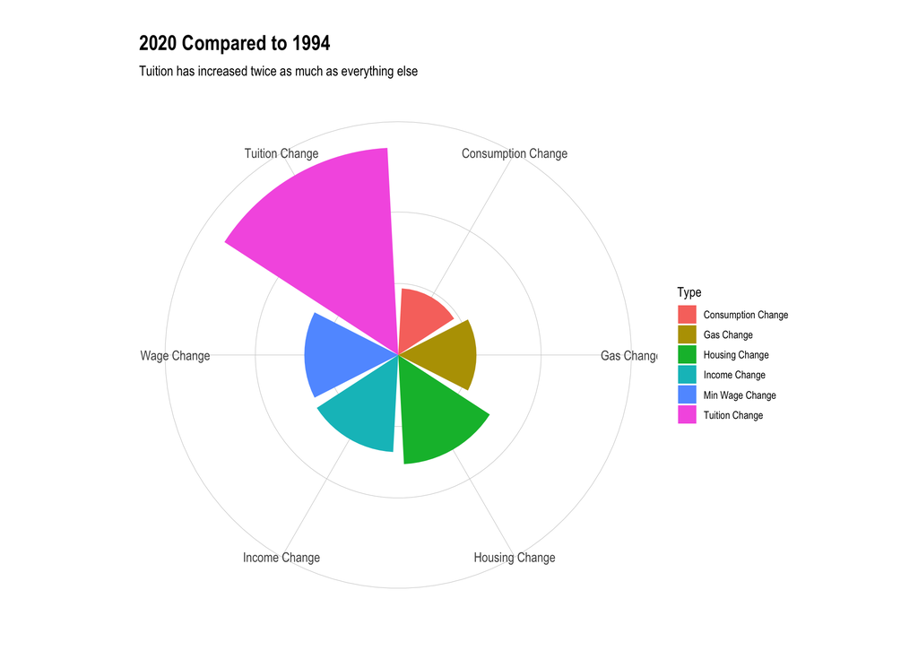

```r
ggplot(data = NowChange) +
  geom_bar(aes(x = Type, y = Change, fill = Type), stat = "identity") +
  coord_polar(theta = "x", direction = 1) +
  theme_ipsum() +
  xlab("") +
  ylab("") +
  ggtitle("2020 Compared to 1994", "Tuition has increased twice as much as everything else") +
  theme(axis.text.y = element_blank())
```

### Tuition’s Rise Makes Loans Unavoidable

Tuition’s continued rise will mean an ever increasing amount of outstanding student loans, and a worsening of what has already been dubbed a crisis. This is especially troubling if the average minimum wage and income continue to increase at the same rate. Tuition’s rise compared to the rise of income and minimum wage can be seen in the graphic below:

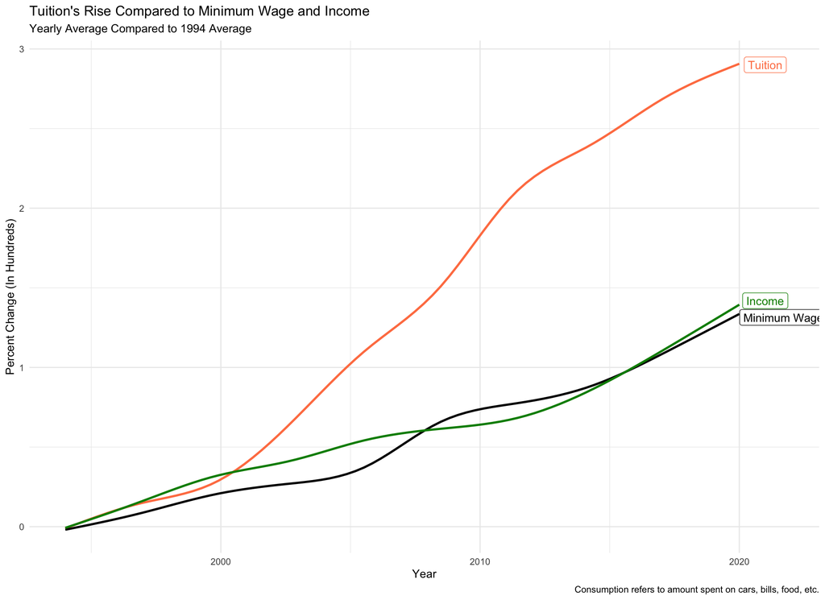

```r
ggplot(data = Main) +
  geom_smooth(aes(x = Year, y = `Tuition Change`), colour = "coral", alpha = .4, se = F, method = "gam") +
  geom_smooth(aes(Year, `Min Wage Change`), colour = "black", se = F, method = "gam") +
  geom_smooth(aes(Year, `Income Change`), colour = "green4", se = F, method = "gam") +
  geom_label(data = Main %>% filter(Year == "2020"), aes(2020, `Income Change`, label = "Income"), nudge_x = 1, nudge_y = .06, colour = "green4") +
  geom_label(data = Main %>% filter(Year == "2020"), aes(2020, `Min Wage Change`, label = "Minimum Wage"), nudge_x = 1.7, nudge_y = 0) +
  geom_label(data = Main %>% filter(Year == "2020"), aes(2020, `Tuition Change`, label = "Tuition"), nudge_x = 1, colour = "coral") +
  theme_minimal() +
  labs(title = "Tuition's Rise Compared to Minimum Wage and Income", subtitle = "Yearly Average Compared to 1994 Average", caption = "Consumption refers to amount spent on cars, bills, food, etc.") +
  ylab("Percent Change (In Hundreds)")
```

Average income and minimum wage have increased at a much smaller rate than tuition, making student loans nearly unavoidable. If tuition continues to rise at the same rate as it has since 1994, the gap between tuition and income will continue to increase as well. This will leave students no other option than to either skip college or pay for school entirely with student loans. This increase in tuition is either a stand-alone increase or due to other factors, but other monetary factors to indicate market growth have grown at a much smaller rate.

## Predicting Future Tuition

### Outstanding Debt

#### Unduplicated Recipients Regression

This regression is first used to predict the number of outstanding recipients in a given year, making the assumption that the number of unduplicated recipients increases in a linear form. This model uses the formula below:

$$\underbrace{Y_i}_{Recipients} = \beta_0+\beta_1\times
X_i+\epsilon_i\text{ where }\epsilon\sim N(0, \sigma^2)\\\text{and
}i=\text{Federal Fiscal Year}$$

```r
set.seed(121)
n <- 11
keep <- sample(1:nrow(Debt), n)
debttrain <- Debt[keep, ]
debttest <- Debt[-keep, ]
undoclm <- lm(`Unduplicated Recipients    (in millions)` ~ `Federal Fiscal Year2`, data = debttrain)
pander(undoclm)
```

Fitting linear model: `Unduplicated Recipients (in millions)` ~ `Federal Fiscal Year2`

|  | Estimate | Std. Error | t value | Pr(>\|t\|) |
| --- | --- | --- | --- | --- |
| **(Intercept)** | -1856 | 234.8 | -7.906 | 2.433e-05 |
| **`Federal Fiscal Year2`** | 0.9404 | 0.1165 | 8.072 | 2.061e-05 |

We can see from the summary that fiscal year is significant at the .001 level of significance. Plotting the regression gives us the plot below, where the dots are the actual value for the year and the line is the predicted value:

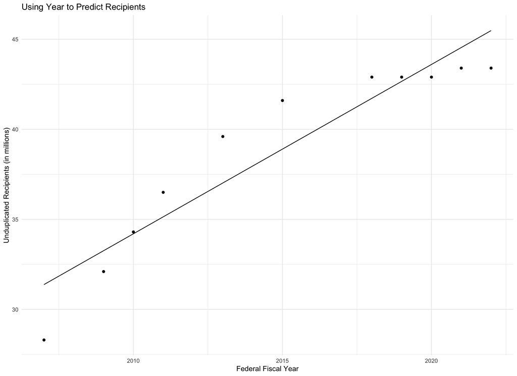

```r
s <- coefficients(undoclm)
srh <- predict.lm(undoclm, newdata = debttest, na.action = na.pass)
ybars <- mean(debttest$`Unduplicated Recipients    (in millions)`)
sstohs <- sum( (debttest$`Unduplicated Recipients    (in millions)` - ybars)^2 )
ssehs <- sum( (debttest$`Unduplicated Recipients    (in millions)` - srh)^2 )
rshs <- 1 - ssehs/sstohs
ns <- length(debttest$`Unduplicated Recipients    (in millions)`)
hts <- length(coef(undoclm))
rshas <- 1 - (ns - 1)/(ns - hts)*ssehs/sstohs

ggplot(debttrain, aes(`Federal Fiscal Year2`, `Unduplicated Recipients    (in millions)`)) +
  geom_point() +
  stat_function(fun = function(x) s[1] + s[2]*x) +
  ylab("Unduplicated Recipients (in millions)") +
  xlab("Federal Fiscal Year") +
  ggtitle("Using Year to Predict Recipients") +
  theme_minimal()
```

Using the data that was set aside for validation gives us the values for $R^2$ below:

```r
outputs <- data.frame(`Original R^2` = summary(undoclm)$r.squared, `Original Adjusted R^2` = summary(undoclm)$adj.r.squared, `Validation R^2` = rshs, `Validation Adjusted R^2` = rshas)
colnames(outputs) <- c("Original $R^2$ # of Students", "Original Adjusted $R^2$ # of Students", "Validation $R^2$ # of Students", "Validation Adjusted $R^2$ # of Students")
pander(outputs)
```

Table continues below

| Original $R^2$ # of Students | Original Adjusted $R^2$ # of Students |
| --- | --- |
| 0.8786 | 0.8651 |

| Validation $R^2$ # of Students | Validation Adjusted $R^2$ # of Students |
| --- | --- |
| 0.7481 | 0.6641 |

These values tell us that this model isn’t perfect, but is an alright predictor of the number of unduplicated recipients.

#### Oustanding Debt Regression

We’ll use the same approach to model outstanding debt, using unduplicated recipients to predict dollars outstanding:

$$\underbrace{Y_i}_{Dollars} = \alpha_0+\alpha_1\times X_i +
\epsilon_i\text{ where }\epsilon\sim N(0, \sigma^2)\\\text{and
}i=\text{Number of Recipients}$$

```r
debtlm <- lm(`Dollars Outstanding            (in billions)` ~ `Unduplicated Recipients    (in millions)`, data = debttrain)
pander(debtlm)
```

Fitting linear model: `Dollars Outstanding (in billions)` ~ `Unduplicated Recipients (in millions)`

|  | Estimate | Std. Error | t value | Pr(>\|t\|) |
| --- | --- | --- | --- | --- |
| **(Intercept)** | -1756 | 286.9 | -6.12 | 0.0001749 |
| **`Unduplicated Recipients (in millions)`** | 74.95 | 7.313 | 10.25 | 2.915e-06 |

The table above shows us that the number of recipients is a significant factor in predicting dollars outstanding at the .001 level of significance. The plot below shows the number of actual dollars outstanding based plotted against number of recipients:

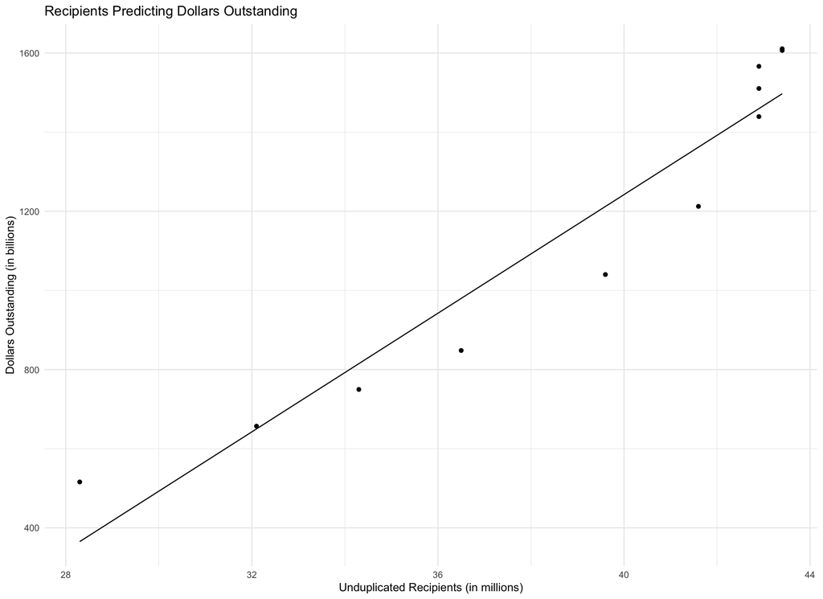

```r
hd <- coefficients(debtlm)
prhd <- predict.lm(debtlm, newdata = debttest, na.action = na.pass)
ybard <- mean(debttest$`Dollars Outstanding            (in billions)`)
sstohd <- sum( (debttest$`Dollars Outstanding            (in billions)` - ybard)^2 )
ssehd <- sum( (debttest$`Dollars Outstanding            (in billions)` - prhd)^2 )
rshd <- 1 - ssehd/sstohd
nd <- length(debttest$`Dollars Outstanding            (in billions)`)
htd <- length(coef(debtlm))
rshad <- 1 - (nd - 1)/(nd - htd)*ssehd/sstohd

ggplot(debttrain, aes(`Unduplicated Recipients    (in millions)`, `Dollars Outstanding            (in billions)`)) +
  geom_point() +
  stat_function(fun = function(x) hd[1] + hd[2]*x) +
  theme_minimal() +
  xlab("Unduplicated Recipients (in millions)") +
  ylab("Dollars Outstanding (in billions)") +
  ggtitle("Recipients Predicting Dollars Outstanding")
```

The table below shows that the model is a good fit for predicting dollars outstanding with an adjusted $R^2$ above .7:

```r
outputd <- data.frame(`Original R^2` = summary(debtlm)$r.squared, `Original Adjusted R^2` = summary(debtlm)$adj.r.squared, `Validation R^2` = rshd, `Validation Adjusted R^2` = rshad)
colnames(outputd) <- c("Original $R^2$ # of Students", "Original Adjusted $R^2$ # of Students", "Validation $R^2$ # of Students", "Validation Adjusted $R^2$ # of Students")
pander(outputd)
```

Table continues below

| Original $R^2$ # of Students | Original Adjusted $R^2$ # of Students |
| --- | --- |
| 0.9211 | 0.9123 |

| Validation $R^2$ # of Students | Validation Adjusted $R^2$ # of Students |
| --- | --- |
| 0.7914 | 0.7218 |

#### Predictions

Using the regressgions above, the values for 2025 and 2030 are predicted below:

```r
ttf <- -1856 + 2025*.9404
tth <- -1856 + 2030*.9404
dtf <- -1756 + 74.95*48.31
dth <- -1756 + 74.95*53.012

outputo <- data.frame(Year = c(2025, 2030), ttfo = c(ttf, tth), dtfo = c(dtf, dth))
colnames(outputo) <- c("Year", "Unduplicated Recipients (millions)", "Oustanding Dollars (billions)")
pander(outputo, caption = "Predicted Debts and Loan Recipients in 2025 and 2030")
```

Predicted Debts and Loan Recipients in 2025 and 2030

| Year | Unduplicated Recipients (millions) | Oustanding Dollars (billions) |
| --- | --- | --- |
| 2025 | 48.31 | 1865 |
| 2030 | 53.01 | 2217 |

If the number of undergraduates is assumed to continue to drop or even remain constant around 15 million students, this would mean that there are 38 million people in the United States still owing college debts. This would leave each of those individuals with an average of 41.8 thousand dollars of debt still owed for their college educations.

### Tuition

Using a regression to predict the average tuition, two models were used and compared. The first was for the year, giving the model:

$$\underbrace{Y_i}_\text{Average Tuition}=\nu_0+\nu_1\times x_i
+\epsilon_i \text{ where }\epsilon\sim N(0, \sigma^2)\\\text{and
}i=\text{Year}$$
The second model uses the model given by the equation:
$$\underbrace{Y_i}_\text{Average Tuition}=\nu_0+\nu_1\times x_i
+\epsilon_i \text{ where }\epsilon\sim N(0, \sigma^2)\\\text{and
}i=\text{Average Income}$$

**The summaries for these tests are shown below:**

```r
tuilm <- lm(`Average Tuition` ~ Year, data = Main)
pander(tuilm)
```

Fitting linear model: `Average Tuition` ~ Year

|  | Estimate | Std. Error | t value | Pr(>\|t\|) |
| --- | --- | --- | --- | --- |
| **(Intercept)** | -692001 | 17521 | -39.5 | 2.003e-25 |
| **Year** | 348 | 8.728 | 39.87 | 1.555e-25 |

```r
fallm <- lm(`Average Tuition` ~ `Average Income`, data = Main)
pander(fallm)
```

Fitting linear model: `Average Tuition` ~ `Average Income`

|  | Estimate | Std. Error | t value | Pr(>\|t\|) |
| --- | --- | --- | --- | --- |
| **(Intercept)** | -4818 | 713.7 | -6.75 | 3.006e-07 |
| **`Average Income`** | 0.426 | 0.02589 | 16.45 | 1.343e-15 |

Both of these factors are seen to be significant, but this only tells us that, as tuition is rising, both year and average income are also rising. What might be more telling is comparing the $R^2$ and Adjusted $R^2$ of the two regressions.

```r
outputf <- data.frame(`Year R^2` = summary(tuilm)$r.squared, `Year Adjusted R^2` = summary(tuilm)$adj.r.squared, `Income R^2` = summary(fallm)$r.squared, `Income Adjusted R^2` = summary(fallm)$r.squared)
colnames(outputf) <- c("Year $R^2$", "Year Adjusted $R^2$", "Income $R^2$", "Income Adjusted $R^2$")
pander(outputf, caption = "Comparing Year and Income as Factors")
```

Comparing Year and Income as Factors

| Year $R^2$ | Year Adjusted $R^2$ | Income $R^2$ | Income Adjusted $R^2$ |
| --- | --- | --- | --- |
| 0.9833 | 0.9827 | 0.9093 | 0.9093 |

Through comparing these, it can be seen that using year as a factor of predicting tuition is closer to 1 than using average income as a factor. This tells us that Average Income and Average Tuition, though both rising, are rising disproportionately to one another. Using the regression for year to predict the average tuition in 2025 and 2030 gives us the table below:

```r
tuf <- -692001 + 348 * 2025
tut <- -692001 + 348 * 2030
outputf <- data.frame(Year = c(2025, 2030), `Average Tuition` = c(tuf, tut))
colnames(outputf) <- c("Fiscal Year", "Predicted Average Tuition")
pander(outputf, caption = "Comparing Year and Income as Factors")
```

| Fiscal Year | Predicted Average Tuition |
| --- | --- |
| 2025 | 12699 |
| 2030 | 14439 |

Looking at how this will stack up to average household income, we look at the regression given by the equation:

$$\underbrace{Y_i}_\text{Average Income}=\nu_0+\nu_1\times x_i +\epsilon_i
\text{ where }\epsilon\sim N(0, \sigma^2)\\\text{and }i=\text{Year}$$
This regression is summarised in the table below:

```r
inlm <- lm(`Average Income` ~ Year, data = Main)
pander(inlm)
```

Fitting linear model: `Average Income` ~ Year

|  | Estimate | Std. Error | t value | Pr(>\|t\|) |
| --- | --- | --- | --- | --- |
| **(Intercept)** | -1513142 | 65537 | -23.09 | 2.596e-19 |
| **Year** | 767.1 | 32.65 | 23.5 | 1.649e-19 |

Using this equation, we can predict the average household income in 2025 and 2030. The results, along with the percent of income predicted to be spent on tuition, is summarized in the table below:

```r
iuf <- -1513142 + 767.1 * 2025
iut <- -1513142 + 767.1 * 2030
difi <- tuf/iuf
difu <- tut/iut
now <- 10570/39052

outputi <- data.frame(Year = c(2020, 2025, 2030), `Average Tuition` = c(39052, iuf, iut), `Percent Spent on Tuition` = c(now, difi, difu))
colnames(outputi) <- c("Fiscal Year", "Predicted Average Household Income", "Percent Spent on Tuition")
pander(outputi)
```

| Fiscal Year | Predicted Average Household Income | Percent Spent on Tuition |
| --- | --- | --- |
| 2020 | 39052 | 0.2707 |
| 2025 | 40236 | 0.3156 |
| 2030 | 44071 | 0.3276 |

Notice how, despite the rise in average household income, a higher percent of the household’s income is spent on tuition. However, as the number of unduplicated recipients of student loans is projected to rise, it can be assumed that many students will take on college by taking on loans instead of having the support of a household income.

*What accounts for the steady increase in outstanding student loans despite the recent decrease in college undergraduates?*

*What can students in the near future expect to pay for college? What debt will this leave them with?*

## Sources

**The data used in this project was gathered from the following sources:**

1. https://research.collegeboard.org/trends/college-pricing/highlights
2. https://fred.stlouisfed.org/series/ASPUS#0
3. https://www.eia.gov/dnav/pet/hist/LeafHandler.ashx?n=pet&s=emm_epm0_pte_nus_dpg&f=a
4. https://www.statista.com/statistics/247455/annual-us-consumer-expenditures/
5. https://www.census.gov/data/tables/time-series/demo/income-poverty/historical-income-people.html
6. https://www.kaggle.com/datasets/lislejoem/us-minimum-wage-by-state-from-1968-to-2017?resource=download
7. https://data.bls.gov/pdq/SurveyOutputServlet
8. https://studentaid.gov/data-center/student/portfolio